# Effects of Bike Hiring

## Mitesh Kavaiya

## Investigation Overview

I selected Ford GoBike dataset in order to investigate bike hiring by different people. There are a lot of different variables and our main focus is to define the most common variables which effect the bike hiring program in San Francisco

## Age Distrubition of Riders

Ages from 18 to 56 takes 95% of the users. There are users more than 100 years old. We can remove users more than 60 years old.

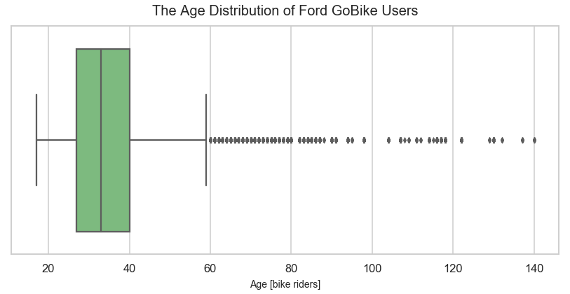

```python
plt.figure(figsize=(14,6))
sns.boxplot(x='member_age', data=df, palette='Greens', orient='h')
plt.title("The Age Distribution of Ford GoBike Users", fontsize=20, y=1.03)
plt.xlabel("Age [bike riders]", fontsize=14, labelpad=8)
plt.savefig('image01.png');
```

During the winter months of November, December and part of January, there is a drastic decrease in riders.

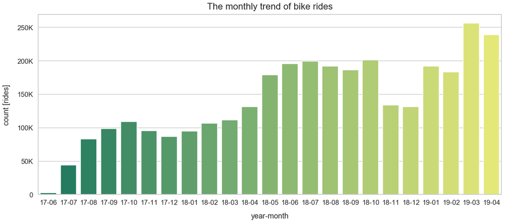

```python
plt.figure(figsize=(20,8))
sns.countplot(x='start_time_year_month_renamed', palette="summer", data=df.sort_values(by='start_time_year_month_renamed'))
plt.title('The monthly trend of bike rides', fontsize=22, y=1.015)
plt.xlabel('year-month', labelpad=16)
plt.ylabel('count [rides]', labelpad=16)
ax = plt.gca()
ax.yaxis.set_major_formatter(tick.FuncFormatter(transform_axis_fmt))
plt.savefig('image03.png')
```

## Monthly Trend of Age Groups

20-30 years old users are rapidly growing compared to other user groups. When the service first started 30-40 years old users were dominant, however 20-30 years old users became leader in a year.

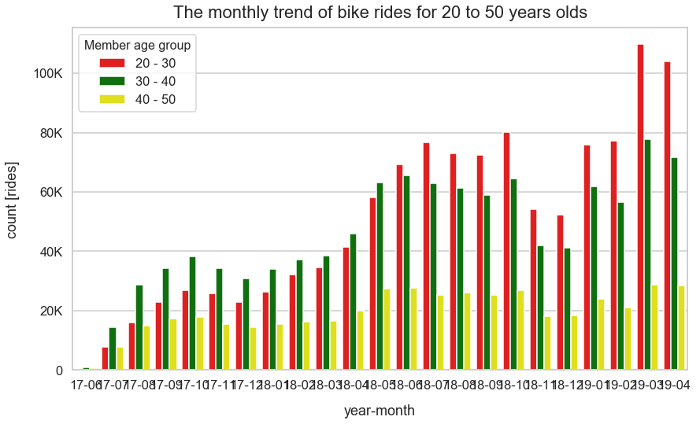

```python
plt.figure(figsize=(14,8))
my_palette = {'20 - 30': 'red', '30 - 40': 'green', '40 - 50': 'yellow'}
ax = sns.countplot(x='start_time_year_month_renamed', hue='member_age_bins', palette=my_palette, data=df[df['member_age_bins'].isin(['20 - 30', '30 - 40', '40 - 50'])].sort_values(by=['start_time_year_month_renamed', 'member_age_bins']))
plt.title('The monthly trend of bike rides for 20 to 50 years olds', fontsize=22, y=1.015)
plt.xlabel('year-month', labelpad=16)
plt.ylabel('count [rides]', labelpad=16)
leg = ax.legend()
leg.set_title('Member age group',prop={'size':16})
ax = plt.gca()
ax.yaxis.set_major_formatter(tick.FuncFormatter(transform_axis_fmt))
plt.savefig('image04.png');
```

### Usage time of GoBike

Subscribers are most frequently used this service around 7~9am and 4~6pm. Customers are used this service at weekend around 10am~5pm and weekday 5pm~6pm. Customers use this service during weekend for leisure and weekdays after work.

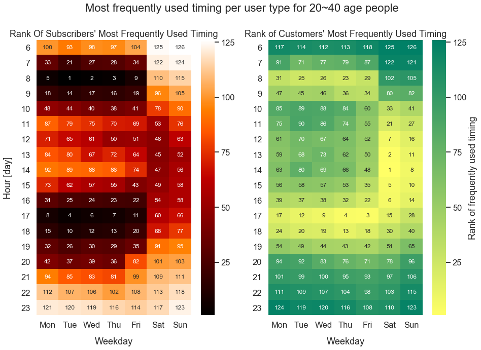

```python
plt.figure(figsize=(15,10))
plt.subplot(121)
plt.suptitle('Most frequently used timing per user type for 20~40 age people', fontsize=22)
sns.heatmap(subscriber_hour_df_pivoted, fmt='d', annot=True, cmap='gist_heat', annot_kws={"size": 12})
plt.title("Rank Of Subscribers' Most Frequently Used Timing", y=1.015)
plt.xlabel('Weekday', labelpad=16)
plt.ylabel('Hour [day]', labelpad=16)
plt.yticks(rotation=360)
plt.subplot(122)
sns.heatmap(customer_hour_df_pivoted, fmt='d', annot=True, cmap='summer_r', annot_kws={"size": 12}, cbar_kws={'label': 'Rank of frequently used timing'})
plt.title("Rank of Customers' Most Frequently Used Timing", y=1.015)
plt.xlabel('Weekday', labelpad=16)
plt.ylabel(' ')
plt.yticks(rotation=360)
plt.savefig('image13.png');
```